# Biostat 212a Homework 5

Due Mar 16, 2024 @ 11:59PM

Author

Li Zhang 206305918

Published

March 15, 2024

```r
library(GGally)
library(gtsummary)
library(ranger)
library(tidyverse)
library(tidymodels)
library(ISLR2)
library(magrittr)

library(kernlab)
```

## 1 ISL Exercise 9.7.1 (10pts)

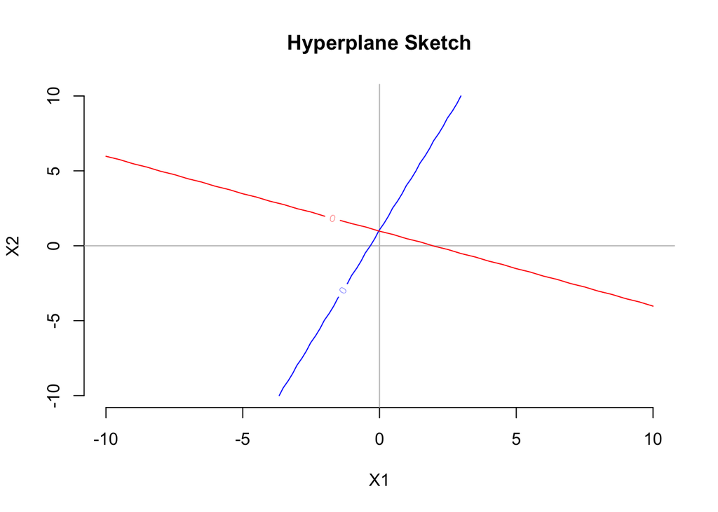

```r
X1 <- seq(-10, 10, by = 0.5)
X2 <- seq(-10, 10, by = 0.5)

grid <- expand.grid(X1, X2)

grid$X2_hyperplane1 <- 1 + 3 * grid$Var1 - grid$Var2
grid$X2_hyperplane2 <- (-2 + grid$Var1 + 2 * grid$Var2) / 2

# Plot the hyperplane
plot(grid$Var1, grid$Var2, type = "n", xlab = "X1", ylab = "X2",
     main = "Hyperplane Sketch", frame.plot = FALSE)
abline(h = 0, v = 0, col = "gray")
contour(X1, X2, matrix(grid$X2_hyperplane1, length(X1), length(X2)),
        levels = 0, add = TRUE, col = "blue")
contour(X1, X2, matrix(grid$X2_hyperplane2, length(X1), length(X2)),
        levels = 0, add = TRUE, col = "red")
```

The blue line represents the hyperplane defined by $1 + 3X_1 - X_2 = 0$

The red line represents the hyperplane defined by $-2 + X_1 + 2X_2 = 0$.

The set of points for which $-2 + X_1 + 2X_2 > 0$ is the set of points **above** the red hyperplane.

The set of points for which $-2 + X_1 + 2X_2 < 0$ is the set of points **below** the red hyperplane.

## 2 ISL Exercise 9.7.2 (10pts)

[figure not shown]

```r
center <- c(-1, sqrt(2))
radius <- 2

theta <- seq(0, 2 * pi, length.out = 100)

x <- center[1] + radius * cos(theta)
y <- center[2] + radius * sin(theta)

plot(x, y, type = "l", asp = 1, xlab = "X", ylab = "Y", main = "(1 + X_1)^2 + (2 - X_2)^2 = 4")
polygon(x, y, col = "lightblue")
abline(h = 0, v = 0, col = "gray")
```

The set of points for which $(1 + X_1)^2 + (2 - X_2)^2 > 4$ is the set of points outside the blue circle.

The decision boundary: $(1 + X_1)^2 + (2 - X_2)^2 = 4$

So, it is not linear in terms of $X_1$ and $X_2$.

then it is linear in terms of $X_1$, $X_2$, $X_1^2$, and $X_2^2$.

## 3 Support vector machines (SVMs) on the `Carseats` data set (30pts)

Follow the machine learning workflow to train support vector classifier (same as SVM with linear kernel), SVM with polynomial kernel (tune the degree and regularization parameter $C$), and SVM with radial kernel (tune the scale parameter $\gamma$ and regularization parameter $C$) for classifying `Sales<=8` versus `Sales>8`. Use the same seed as in your HW4 for the initial test/train split and compare the final test AUC and accuracy to those methods you tried in HW4.

### 3.1 Careseats dataset

```r
str(Carseats)
```

```
'data.frame':   400 obs. of  11 variables:
 $ Sales      : num  9.5 11.22 10.06 7.4 4.15 ...
 $ CompPrice  : num  138 111 113 117 141 124 115 136 132 132 ...
 $ Income     : num  73 48 35 100 64 113 105 81 110 113 ...
 $ Advertising: num  11 16 10 4 3 13 0 15 0 0 ...
 $ Population : num  276 260 269 466 340 501 45 425 108 131 ...
 $ Price      : num  120 83 80 97 128 72 108 120 124 124 ...
 $ ShelveLoc  : Factor w/ 3 levels "Bad","Good","Medium": 1 2 3 3 1 1 3 2 3 3 ...
 $ Age        : num  42 65 59 55 38 78 71 67 76 76 ...
 $ Education  : num  17 10 12 14 13 16 15 10 10 17 ...
 $ Urban      : Factor w/ 2 levels "No","Yes": 2 2 2 2 2 1 2 2 1 1 ...
 $ US         : Factor w/ 2 levels "No","Yes": 2 2 2 2 1 2 1 2 1 2 ...
```

```r
Carseats$Sales <- ifelse(Carseats$Sales <= 8, "0", "1")
Carseats$Sales <- factor(Carseats$Sales)
```

```r
Carseats <- na.omit(Carseats)
Carseats %>% tbl_summary(by = Sales)
```

| **Characteristic** | **0**, N = 236<sup>1</sup> | **1**, N = 164<sup>1</sup> |
| --- | --- | --- |
| CompPrice | 124 (115, 134) | 127 (115, 136) |
| Income | 65 (40, 88) | 76 (58, 94) |
| Advertising | 3.0 (0.0, 10.0) | 10.0 (0.0, 14.0) |
| Population | 268 (132, 389) | 276 (150, 403) |
| Price | 122 (107, 135) | 107 (90, 123) |
| ShelveLoc |  |  |
| Bad | 82 (35%) | 14 (8.5%) |
| Good | 19 (8.1%) | 66 (40%) |
| Medium | 135 (57%) | 84 (51%) |
| Age | 58 (42, 70) | 49 (36, 61) |
| Education |  |  |
| 10 | 23 (9.7%) | 25 (15%) |
| 11 | 31 (13%) | 17 (10%) |
| 12 | 30 (13%) | 19 (12%) |
| 13 | 26 (11%) | 17 (10%) |
| 14 | 26 (11%) | 14 (8.5%) |
| 15 | 18 (7.6%) | 18 (11%) |
| 16 | 29 (12%) | 18 (11%) |
| 17 | 28 (12%) | 21 (13%) |
| 18 | 25 (11%) | 15 (9.1%) |
| Urban | 172 (73%) | 110 (67%) |
| US | 135 (57%) | 123 (75%) |

<sup>1</sup> Median (IQR); n (%)

- The goal is to predict `Sales <= 8` versus `Sales > 8`

### 3.2 Initial split into test and non-test sets

```r
# For reproducibility
set.seed(210)

data_split <- initial_split(
  Carseats,
  prop = 0.5,
  strata = Sales
  )
data_split
```

```
<Training/Testing/Total>
<200/200/400>
```

```r
Carseats_other <- training(data_split)
dim(Carseats_other)
```

```
[1] 200  11
```

```r
Carseats_test <- testing(data_split)
dim(Carseats_test)
```

```
[1] 200  11
```

### 3.3 Support vector classifier

#### 3.3.1 Recipe

```r
svm_recipe <-
  recipe(
    Sales ~ .,
    data = Carseats_other
  ) %>%

  # create traditional dummy variables (necessary for svm)
  step_dummy(all_nominal_predictors()) %>%
  # zero-variance filter
  step_zv(all_numeric_predictors()) %>%
  # center and scale numeric data
  step_normalize(all_numeric_predictors()) %>%
  # estimate the means and standard deviations
  prep(training = Carseats_other, retain = TRUE)
```

#### 3.3.2 Model

```r
svm_mod <-
  svm_linear(
    mode = "classification",
    cost = tune()
  ) %>%
  set_engine("kernlab")
```

#### 3.3.3 Workflow

```r
svm_wf <- workflow() %>%
  add_recipe(svm_recipe) %>%
  add_model(svm_mod)

svm_wf
```

```
══ Workflow ════════════════════════════════════════════════════════════════════
Preprocessor: Recipe
Model: svm_linear()

── Preprocessor ────────────────────────────────────────────────────────────────
3 Recipe Steps

• step_dummy()
• step_zv()
• step_normalize()

── Model ───────────────────────────────────────────────────────────────────────
Linear Support Vector Machine Model Specification (classification)

Main Arguments:
  cost = tune()

Computational engine: kernlab
```

#### 3.3.4 Tuning grid

```r
param_grid <- grid_regular(
  cost(range = c(-3, 2)),
  levels = c(5)
  )
```

#### 3.3.5 CV

Set cross-validation partitions.

```r
set.seed(212)

folds <- vfold_cv(Carseats_other, v = 5)
folds
```

```
#  5-fold cross-validation
# A tibble: 5 × 2
  splits           id
  <list>           <chr>
1 <split [160/40]> Fold1
2 <split [160/40]> Fold2
3 <split [160/40]> Fold3
4 <split [160/40]> Fold4
5 <split [160/40]> Fold5
```

Fit cross-validation.

```r
svm_fit <- svm_wf %>%
  tune_grid(
    resamples = folds,
    grid = param_grid,
    metrics = metric_set(roc_auc, accuracy)
    )
svm_fit
```

```
# Tuning results
# 5-fold cross-validation
# A tibble: 5 × 4
  splits           id    .metrics          .notes
  <list>           <chr> <list>            <list>
1 <split [160/40]> Fold1 <tibble [10 × 5]> <tibble [0 × 3]>
2 <split [160/40]> Fold2 <tibble [10 × 5]> <tibble [0 × 3]>
3 <split [160/40]> Fold3 <tibble [10 × 5]> <tibble [0 × 3]>
4 <split [160/40]> Fold4 <tibble [10 × 5]> <tibble [0 × 3]>
5 <split [160/40]> Fold5 <tibble [10 × 5]> <tibble [0 × 3]>
```

Visualize CV results:

```
# A tibble: 10 × 7
    cost .metric  .estimator  mean     n std_err .config
   <dbl> <chr>    <chr>      <dbl> <int>   <dbl> <chr>
 1 0.125 accuracy binary     0.86      5  0.0218 Preprocessor1_Model1
 2 0.125 roc_auc  binary     0.934     5  0.0254 Preprocessor1_Model1
 3 0.297 accuracy binary     0.865     5  0.0232 Preprocessor1_Model2
 4 0.297 roc_auc  binary     0.938     5  0.0271 Preprocessor1_Model2
 5 0.707 accuracy binary     0.87      5  0.0310 Preprocessor1_Model3
 6 0.707 roc_auc  binary     0.934     5  0.0335 Preprocessor1_Model3
 7 1.68  accuracy binary     0.86      5  0.0359 Preprocessor1_Model4
 8 1.68  roc_auc  binary     0.935     5  0.0316 Preprocessor1_Model4
 9 4     accuracy binary     0.865     5  0.035  Preprocessor1_Model5
10 4     roc_auc  binary     0.934     5  0.0305 Preprocessor1_Model5
```

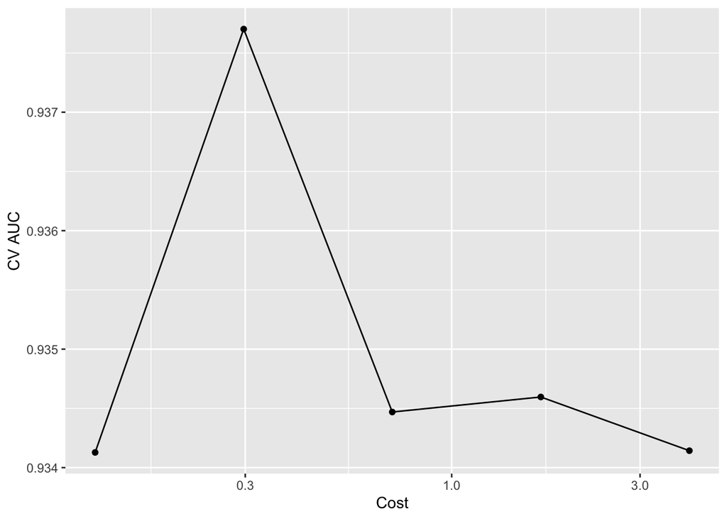

```r
svm_fit %>%
  collect_metrics() %>%
  print(width = Inf) %>%
  filter(.metric == "roc_auc" ) %>%
  ggplot(mapping = aes(x = cost, y = mean)) +
  geom_point() +
  geom_line() +
  labs(x = "Cost", y = "CV AUC") +
  scale_x_log10()
```

Show the top 5 models.

```r
svm_fit %>%
  show_best("roc_auc")
```

```
# A tibble: 5 × 7
   cost .metric .estimator  mean     n std_err .config
  <dbl> <chr>   <chr>      <dbl> <int>   <dbl> <chr>
1 0.297 roc_auc binary     0.938     5  0.0271 Preprocessor1_Model2
2 1.68  roc_auc binary     0.935     5  0.0316 Preprocessor1_Model4
3 0.707 roc_auc binary     0.934     5  0.0335 Preprocessor1_Model3
4 4     roc_auc binary     0.934     5  0.0305 Preprocessor1_Model5
5 0.125 roc_auc binary     0.934     5  0.0254 Preprocessor1_Model1
```

Let’s select the best model.

```r
best_svm <- svm_fit %>%
  select_best("roc_auc")
best_svm
```

```
# A tibble: 1 × 2
   cost .config
  <dbl> <chr>
1 0.297 Preprocessor1_Model2
```

#### 3.3.6 Finalize the model

```r
# Final workflow
final_wf <- svm_wf %>%
  finalize_workflow(best_svm)
final_wf
```

```
══ Workflow ════════════════════════════════════════════════════════════════════
Preprocessor: Recipe
Model: svm_linear()

── Preprocessor ────────────────────────────────────────────────────────────────
3 Recipe Steps

• step_dummy()
• step_zv()
• step_normalize()

── Model ───────────────────────────────────────────────────────────────────────
Linear Support Vector Machine Model Specification (classification)

Main Arguments:
  cost = 0.29730177875068

Computational engine: kernlab
```

```r
# Fit the whole training set, then predict the test cases
final_fit <-
  final_wf %>%
  last_fit(data_split)
final_fit
```

```
# Resampling results
# Manual resampling
# A tibble: 1 × 6
  splits            id               .metrics .notes   .predictions .workflow
  <list>            <chr>            <list>   <list>   <list>       <list>
1 <split [200/200]> train/test split <tibble> <tibble> <tibble>     <workflow>
```

```r
# Test metrics
final_fit %>%
  collect_metrics()
```

```
# A tibble: 2 × 4
  .metric  .estimator .estimate .config
  <chr>    <chr>          <dbl> <chr>
1 accuracy binary         0.88  Preprocessor1_Model1
2 roc_auc  binary         0.954 Preprocessor1_Model1
```

### 3.4 SVM with polynomial kernel

#### 3.4.1 Recipe

```r
svm_recipe <-
  recipe(
    Sales ~ .,
    data = Carseats_other
  ) %>%

  # create traditional dummy variables (necessary for svm)
  step_dummy(all_nominal_predictors()) %>%
  # zero-variance filter
  step_zv(all_numeric_predictors()) %>%
  # center and scale numeric data
  step_normalize(all_numeric_predictors()) %>%
  # estimate the means and standard deviations
  prep(training = Carseats_other, retain = TRUE)
svm_recipe
```

#### 3.4.2 Model

```r
svm_mod <-
  svm_poly(
    mode = "classification",
    cost = tune(),
    degree = tune(),
    # scale_factor = tune()
  ) %>%
  set_engine("kernlab")
svm_mod
```

```
Polynomial Support Vector Machine Model Specification (classification)

Main Arguments:
  cost = tune()
  degree = tune()

Computational engine: kernlab
```

#### 3.4.3 Workflow

```r
svm_wf <- workflow() %>%
  add_recipe(svm_recipe) %>%
  add_model(svm_mod)
svm_wf
```

```
══ Workflow ════════════════════════════════════════════════════════════════════
Preprocessor: Recipe
Model: svm_poly()

── Preprocessor ────────────────────────────────────────────────────────────────
3 Recipe Steps

• step_dummy()
• step_zv()
• step_normalize()

── Model ───────────────────────────────────────────────────────────────────────
Polynomial Support Vector Machine Model Specification (classification)

Main Arguments:
  cost = tune()
  degree = tune()

Computational engine: kernlab
```

#### 3.4.4 Tuning grid

```r
param_grid <- grid_regular(
  cost(range = c(-3, 2)),
  degree(range = c(1, 5)),
  #scale_factor(range = c(-1, 1)),
  levels = c(5)
  )
param_grid
```

```
# A tibble: 25 × 2
    cost degree
   <dbl>  <dbl>
 1 0.125      1
 2 0.297      1
 3 0.707      1
 4 1.68       1
 5 4          1
 6 0.125      2
 7 0.297      2
 8 0.707      2
 9 1.68       2
10 4          2
# ℹ 15 more rows
```

#### 3.4.5 CV

Set cross-validation partitions.

```r
set.seed(212)

folds <- vfold_cv(Carseats_other, v = 5)
folds
```

```
#  5-fold cross-validation
# A tibble: 5 × 2
  splits           id
  <list>           <chr>
1 <split [160/40]> Fold1
2 <split [160/40]> Fold2
3 <split [160/40]> Fold3
4 <split [160/40]> Fold4
5 <split [160/40]> Fold5
```

Fit cross-validation.

```r
svm_fit <- svm_wf %>%
  tune_grid(
    resamples = folds,
    grid = param_grid,
    metrics = metric_set(roc_auc, accuracy)
    )
svm_fit
```

```
# Tuning results
# 5-fold cross-validation
# A tibble: 5 × 4
  splits           id    .metrics          .notes
  <list>           <chr> <list>            <list>
1 <split [160/40]> Fold1 <tibble [50 × 6]> <tibble [0 × 3]>
2 <split [160/40]> Fold2 <tibble [50 × 6]> <tibble [0 × 3]>
3 <split [160/40]> Fold3 <tibble [50 × 6]> <tibble [0 × 3]>
4 <split [160/40]> Fold4 <tibble [50 × 6]> <tibble [0 × 3]>
5 <split [160/40]> Fold5 <tibble [50 × 6]> <tibble [0 × 3]>
```

Visualize CV results:

```
# A tibble: 50 × 8
    cost degree .metric  .estimator  mean     n std_err .config
   <dbl>  <dbl> <chr>    <chr>      <dbl> <int>   <dbl> <chr>
 1 0.125      1 accuracy binary     0.86      5  0.0218 Preprocessor1_Model01
 2 0.125      1 roc_auc  binary     0.934     5  0.0254 Preprocessor1_Model01
 3 0.297      1 accuracy binary     0.865     5  0.0232 Preprocessor1_Model02
 4 0.297      1 roc_auc  binary     0.937     5  0.0276 Preprocessor1_Model02
 5 0.707      1 accuracy binary     0.87      5  0.0310 Preprocessor1_Model03
 6 0.707      1 roc_auc  binary     0.934     5  0.0335 Preprocessor1_Model03
 7 1.68       1 accuracy binary     0.86      5  0.0359 Preprocessor1_Model04
 8 1.68       1 roc_auc  binary     0.935     5  0.0316 Preprocessor1_Model04
 9 4          1 accuracy binary     0.865     5  0.035  Preprocessor1_Model05
10 4          1 roc_auc  binary     0.934     5  0.0305 Preprocessor1_Model05
# ℹ 40 more rows
```

[figure not shown]

```r
svm_fit %>%
  collect_metrics() %>%
  print(width = Inf) %>%
  filter(.metric == "roc_auc" ) %>%
  ggplot(mapping = aes(x = degree, y = mean)) +
  geom_point() +
  geom_line() +
  labs(x = "Cost", y = "CV AUC") +
  scale_x_log10()
```

Show the top 5 models.

```r
svm_fit %>%
  show_best("roc_auc")
```

```
# A tibble: 5 × 8
   cost degree .metric .estimator  mean     n std_err .config
  <dbl>  <dbl> <chr>   <chr>      <dbl> <int>   <dbl> <chr>
1 0.297      1 roc_auc binary     0.937     5  0.0276 Preprocessor1_Model02
2 1.68       1 roc_auc binary     0.935     5  0.0316 Preprocessor1_Model04
3 0.707      1 roc_auc binary     0.934     5  0.0335 Preprocessor1_Model03
4 4          1 roc_auc binary     0.934     5  0.0305 Preprocessor1_Model05
5 0.125      1 roc_auc binary     0.934     5  0.0254 Preprocessor1_Model01
```

Let’s select the best model.

```r
best_svm <- svm_fit %>%
  select_best("roc_auc")
best_svm
```

```
# A tibble: 1 × 3
   cost degree .config
  <dbl>  <dbl> <chr>
1 0.297      1 Preprocessor1_Model02
```

#### 3.4.6 Finalize the model

```r
# Final workflow
final_wf <- svm_wf %>%
  finalize_workflow(best_svm)
final_wf
```

```
══ Workflow ════════════════════════════════════════════════════════════════════
Preprocessor: Recipe
Model: svm_poly()

── Preprocessor ────────────────────────────────────────────────────────────────
3 Recipe Steps

• step_dummy()
• step_zv()
• step_normalize()

── Model ───────────────────────────────────────────────────────────────────────
Polynomial Support Vector Machine Model Specification (classification)

Main Arguments:
  cost = 0.29730177875068
  degree = 1

Computational engine: kernlab
```

```r
# Fit the whole training set, then predict the test cases
final_fit <-
  final_wf %>%
  last_fit(data_split)
final_fit
```

```
# Resampling results
# Manual resampling
# A tibble: 1 × 6
  splits            id               .metrics .notes   .predictions .workflow
  <list>            <chr>            <list>   <list>   <list>       <list>
1 <split [200/200]> train/test split <tibble> <tibble> <tibble>     <workflow>
```

```r
# Test metrics
final_fit %>%
  collect_metrics()
```

```
# A tibble: 2 × 4
  .metric  .estimator .estimate .config
  <chr>    <chr>          <dbl> <chr>
1 accuracy binary         0.88  Preprocessor1_Model1
2 roc_auc  binary         0.954 Preprocessor1_Model1
```

### 3.5 SVM with radial kernel

#### 3.5.1 Recipe

```r
svm_recipe <-
  recipe(
    Sales ~ .,
    data = Carseats_other
  ) %>%

  # create traditional dummy variables (necessary for svm)
  step_dummy(all_nominal_predictors()) %>%
  # zero-variance filter
  step_zv(all_numeric_predictors()) %>%
  # center and scale numeric data
  step_normalize(all_numeric_predictors()) %>%
  # estimate the means and standard deviations
  prep(training = Carseats_other, retain = TRUE)
svm_recipe
```

#### 3.5.2 Model

```r
svm_mod <-
  svm_rbf(
    mode = "classification",
    cost = tune(),
    rbf_sigma = tune()
  ) %>%
  set_engine("kernlab")
svm_mod
```

```
Radial Basis Function Support Vector Machine Model Specification (classification)

Main Arguments:
  cost = tune()
  rbf_sigma = tune()

Computational engine: kernlab
```

#### 3.5.3 Workflow

```r
svm_wf <- workflow() %>%
  add_recipe(svm_recipe) %>%
  add_model(svm_mod)
svm_wf
```

```
══ Workflow ════════════════════════════════════════════════════════════════════
Preprocessor: Recipe
Model: svm_rbf()

── Preprocessor ────────────────────────────────────────────────────────────────
3 Recipe Steps

• step_dummy()
• step_zv()
• step_normalize()

── Model ───────────────────────────────────────────────────────────────────────
Radial Basis Function Support Vector Machine Model Specification (classification)

Main Arguments:
  cost = tune()
  rbf_sigma = tune()

Computational engine: kernlab
```

#### 3.5.4 Tuning grid

```r
param_grid <- grid_regular(
  cost(range = c(-8, 5)),
  rbf_sigma(range = c(-5, -3)),
  levels = c(14, 5)
  )
param_grid
```

```
# A tibble: 70 × 2
      cost rbf_sigma
     <dbl>     <dbl>
 1 0.00391   0.00001
 2 0.00781   0.00001
 3 0.0156    0.00001
 4 0.0312    0.00001
 5 0.0625    0.00001
 6 0.125     0.00001
 7 0.25      0.00001
 8 0.5       0.00001
 9 1         0.00001
10 2         0.00001
# ℹ 60 more rows
```

#### 3.5.5 CV

Set cross-validation partitions.

```r
set.seed(212)

folds <- vfold_cv(Carseats_other, v = 5)
folds
```

```
#  5-fold cross-validation
# A tibble: 5 × 2
  splits           id
  <list>           <chr>
1 <split [160/40]> Fold1
2 <split [160/40]> Fold2
3 <split [160/40]> Fold3
4 <split [160/40]> Fold4
5 <split [160/40]> Fold5
```

Fit cross-validation.

```r
svm_fit <- svm_wf %>%
  tune_grid(
    resamples = folds,
    grid = param_grid,
    metrics = metric_set(roc_auc, accuracy)
    )
svm_fit
```

```
# Tuning results
# 5-fold cross-validation
# A tibble: 5 × 4
  splits           id    .metrics           .notes
  <list>           <chr> <list>             <list>
1 <split [160/40]> Fold1 <tibble [140 × 6]> <tibble [0 × 3]>
2 <split [160/40]> Fold2 <tibble [140 × 6]> <tibble [0 × 3]>
3 <split [160/40]> Fold3 <tibble [140 × 6]> <tibble [0 × 3]>
4 <split [160/40]> Fold4 <tibble [140 × 6]> <tibble [0 × 3]>
5 <split [160/40]> Fold5 <tibble [140 × 6]> <tibble [0 × 3]>
```

Visualize CV results:

```
# A tibble: 140 × 8
      cost rbf_sigma .metric  .estimator  mean     n std_err
     <dbl>     <dbl> <chr>    <chr>      <dbl> <int>   <dbl>
 1 0.00391   0.00001 accuracy binary     0.59      5  0.0367
 2 0.00391   0.00001 roc_auc  binary     0.857     5  0.0493
 3 0.00781   0.00001 accuracy binary     0.59      5  0.0367
 4 0.00781   0.00001 roc_auc  binary     0.857     5  0.0493
 5 0.0156    0.00001 accuracy binary     0.59      5  0.0367
 6 0.0156    0.00001 roc_auc  binary     0.857     5  0.0493
 7 0.0312    0.00001 accuracy binary     0.59      5  0.0367
 8 0.0312    0.00001 roc_auc  binary     0.857     5  0.0493
 9 0.0625    0.00001 accuracy binary     0.59      5  0.0367
10 0.0625    0.00001 roc_auc  binary     0.857     5  0.0493
   .config
   <chr>
 1 Preprocessor1_Model01
 2 Preprocessor1_Model01
 3 Preprocessor1_Model02
 4 Preprocessor1_Model02
 5 Preprocessor1_Model03
 6 Preprocessor1_Model03
 7 Preprocessor1_Model04
 8 Preprocessor1_Model04
 9 Preprocessor1_Model05
10 Preprocessor1_Model05
# ℹ 130 more rows
```

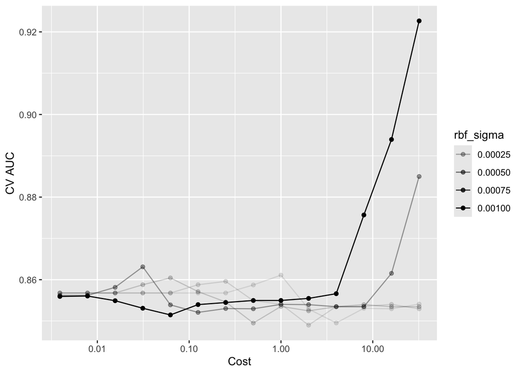

```r
svm_fit %>%
  collect_metrics() %>%
  print(width = Inf) %>%
  filter(.metric == "roc_auc" ) %>%
  ggplot(mapping = aes(x = cost, y = mean, alpha = rbf_sigma)) +
  geom_point() +
  geom_line(aes(group = rbf_sigma)) +
  labs(x = "Cost", y = "CV AUC") +
  scale_x_log10()
```

Show the top 5 models.

```r
svm_fit %>%
  show_best("roc_auc")
```

```
# A tibble: 5 × 8
     cost rbf_sigma .metric .estimator  mean     n std_err .config
    <dbl>     <dbl> <chr>   <chr>      <dbl> <int>   <dbl> <chr>
1 32       0.001    roc_auc binary     0.923     5  0.0311 Preprocessor1_Model70
2 16       0.001    roc_auc binary     0.894     5  0.0428 Preprocessor1_Model69
3 32       0.000316 roc_auc binary     0.885     5  0.0427 Preprocessor1_Model56
4  8       0.001    roc_auc binary     0.876     5  0.0421 Preprocessor1_Model68
5  0.0312  0.000316 roc_auc binary     0.863     5  0.0464 Preprocessor1_Model46
```

Let’s select the best model.

```r
best_svm <- svm_fit %>%
  select_best("roc_auc")
best_svm
```

```
# A tibble: 1 × 3
   cost rbf_sigma .config
  <dbl>     <dbl> <chr>
1    32     0.001 Preprocessor1_Model70
```

#### 3.5.6 Finalize the model

```r
# Final workflow
final_wf <- svm_wf %>%
  finalize_workflow(best_svm)
final_wf
```

```
══ Workflow ════════════════════════════════════════════════════════════════════
Preprocessor: Recipe
Model: svm_rbf()

── Preprocessor ────────────────────────────────────────────────────────────────
3 Recipe Steps

• step_dummy()
• step_zv()
• step_normalize()

── Model ───────────────────────────────────────────────────────────────────────
Radial Basis Function Support Vector Machine Model Specification (classification)

Main Arguments:
  cost = 32
  rbf_sigma = 0.001

Computational engine: kernlab
```

```r
# Fit the whole training set, then predict the test cases
final_fit <-
  final_wf %>%
  last_fit(data_split)
final_fit
```

```
# Resampling results
# Manual resampling
# A tibble: 1 × 6
  splits            id               .metrics .notes   .predictions .workflow
  <list>            <chr>            <list>   <list>   <list>       <list>
1 <split [200/200]> train/test split <tibble> <tibble> <tibble>     <workflow>
```

```r
# Test metrics
final_fit %>%
  collect_metrics()
```

```
# A tibble: 2 × 4
  .metric  .estimator .estimate .config
  <chr>    <chr>          <dbl> <chr>
1 accuracy binary         0.88  Preprocessor1_Model1
2 roc_auc  binary         0.950 Preprocessor1_Model1
```

### 3.6 Summary

| method | accuracy | roc_auc |  |
| --- | --- | --- | --- |
| classification tree | 0.74 | 0.756 |  |
| random forest | 0.785 | 0.861 |  |
| boosting | 0.84 | 0.920 |  |
| support vector classifier | 0.88 | 0.954 |  |
| svm with polynomial kernel | 0.88 | 0.954 |  |
| svm with radial kernel | 0.88 | 0.950 |  |

After comparing the final test AUC and accuracy to those methods you tried in HW4, we can see that the SVM methods have higher AUC and accuracy.

## 4 Bonus (10pts)

Let
$$f(X) = \beta_0 + \beta_1 X_1 + \cdots + \beta_p X_p = \beta_0 + \beta^T X.$$
Then $f(X)=0$ defines a hyperplane in $\mathbb{R}^p$. Show that $f(x)$ is proportional to the signed distance of a point $x$ to the hyperplane $f(X) = 0$.

### 4.1 Solution

To show that $f(x)$ is proportional to the signed distance of a point $x$ to the hyperplane $f(X) = 0$, we need to consider the normal vector of the hyperplane and the geometric interpretation of the linear function $f(X)$.

Let’s first define the normal vector of the hyperplane $f(X) = 0$. The normal vector is given by the coefficients of the linear function $f(X)$, which are $\beta = (\beta_1, \beta_2, \ldots, \beta_p)$.

Now, consider a point $x = (x_1, x_2, \ldots, x_p)$ in $\mathbb{R}^p$. The signed distance of this point $x$ to the hyperplane $f(X) = 0$ is given by:

$$d(x) = \frac{f(x)}{\|\beta\|}$$

where $\|\beta\|$ is the Euclidean norm (length) of the normal vector $\beta$.

From this expression, we can see that $f(x)$ is proportional to the signed distance $d(x)$ with the proportionality constant being $\|\beta\|$, the length of the normal vector.

$$f(x) = \|\beta\| \cdot d(x)$$

Therefore, we have shown that $f(x)$ is proportional to the signed distance of the point $x$ to the hyperplane $f(X) = 0$, with the proportionality constant being the length of the normal vector $\|\beta\|$.

The sign of $f(x)$ (or $d(x)$) indicates which side of the hyperplane the point $x$ lies on. If $f(x) > 0$, the point $x$ lies on one side of the hyperplane, and if $f(x) < 0$, the point $x$ lies on the other side of the hyperplane.